# metabolomic - paper

## Initialization with data

### Read the data from the excel sheet

Since the data is in an `excel sheet` we will ned the library `readxl` to gather our data, we take precautions to select the correct sheet and make sure to only select the data that we actually want.

```r
library(readxl)
data <- read_excel(
  "../Input/Datenbank_Steroide_gruppiert_230421.xlsx",
  skip = 1, sheet = "Steroids", col_names = TRUE
)
```

To make sure that there are only true `variables` in our dataset we used the column `Pat.-Nr.` as the row names and remove it, sex and age from our dataset.

```r
library(dplyr)
dat1 <- data.frame(data, row.names = data$"Pat.-Nr.")

# Remove the Pat.-Nr., Sex and the Age
dat1 <- dat1 %>% select(-1, -2, -3)
```

## Removing non applicable data points

### Removing `Non Applicable` Values

Since our data is containing `na` values, we will have to make sure not to include them in our final calculations, we use the `replacezero` function to replace them with a number half the smallest number found that is still larger than zero.

```r
# Function to Remove all 'NA' from the data
replacezero <- function(x) "[<-"(x, !x | is.na(x), min(x[x > 0], na.rm = TRUE) / 2)

# apply the function to our data, renaming it to 'dat2' in the process
dat2 <- as.data.frame(t(apply(dat1, 1, replacezero)))


sum(is.na(dat2))
```

```
## [1] 0
```

### Transform data to logarithmic with base 2

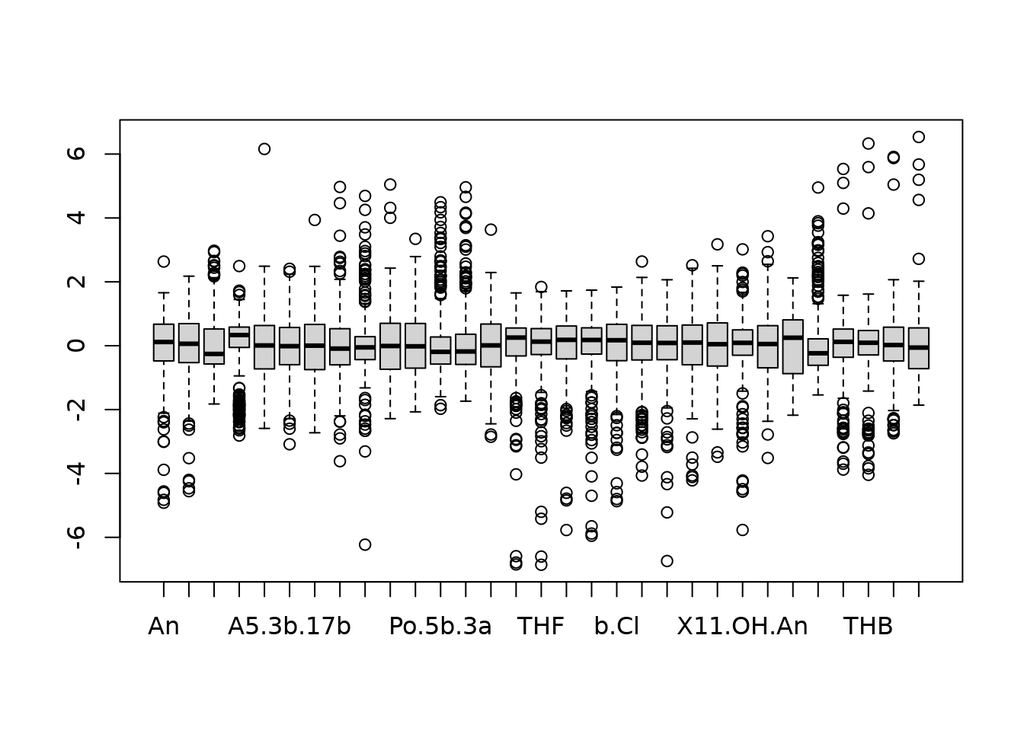

```r
logdata <- log(dat2, 2)

# Function for pareto scaling
paretoscale <- function(z) {
  rowmean <- apply(z, 1, mean) # row means
  rowsd <- apply(z, 1, sd) # row standard deviation
  rowsqrtsd <- sqrt(rowsd) # sqrt of sd
  rv <- sweep(z, 1, rowmean, "-") # mean center
  rv <- sweep(rv, 1, rowsqrtsd, "/") # dividing by sqrtsd
  return(rv)
}

# Pareto scale log transformed data
logdata.pareto <- scale(paretoscale(logdata))

boxplot(logdata.pareto)
```

## Principal Component Analysis

The `Principal Component Analysis` is able to calculate the significance of our data and in turn minimize their dimensions, commonly referred to as `dimension reduction`.

```r
pca <- prcomp(logdata.pareto, center = F, scale = F)

# If one wants toremove the data that is deemed unsignificant
# logdata.pareto <- subset(logdata.pareto, colnames(logdata.pareto) %in% rownames(loadings.sig))
```

## Plotting

### Principal Component Analysis

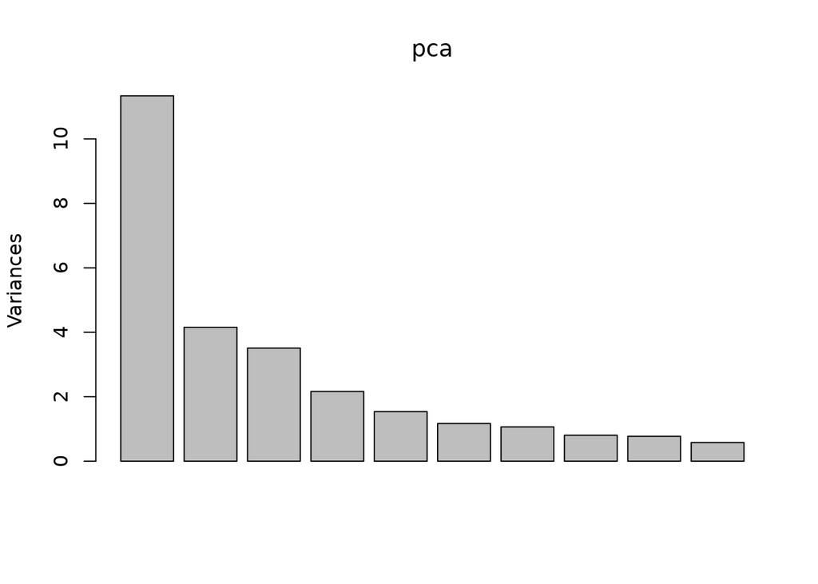

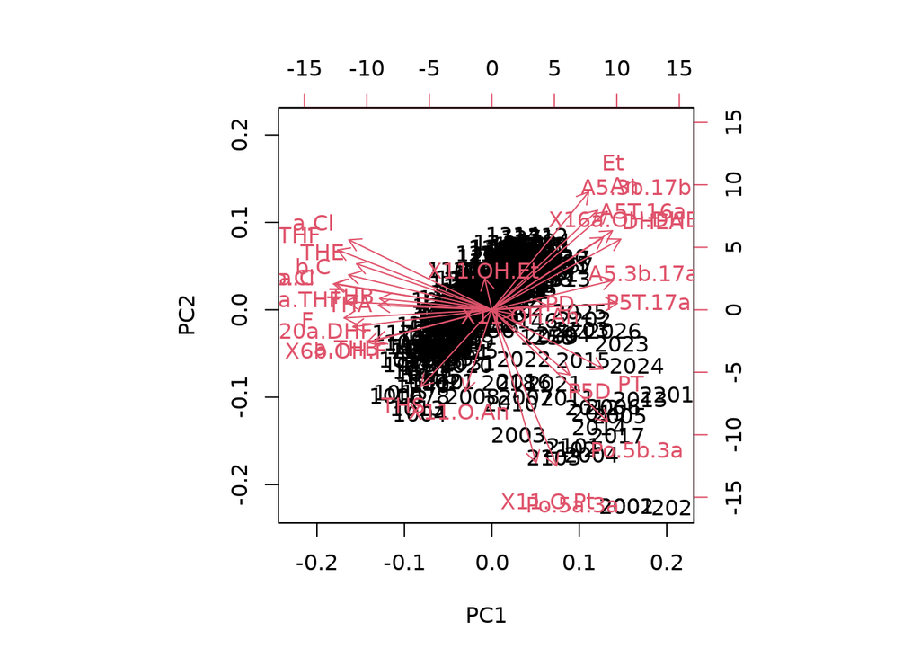

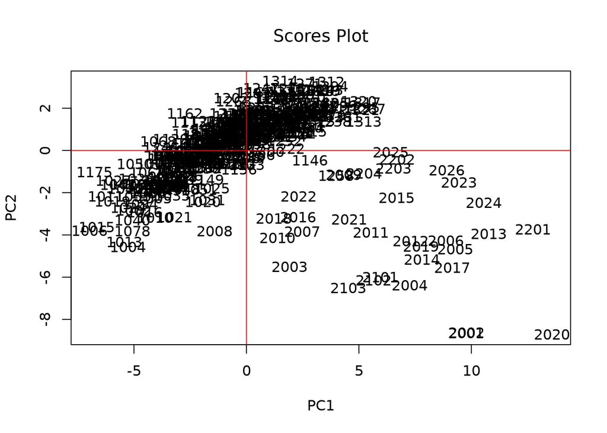

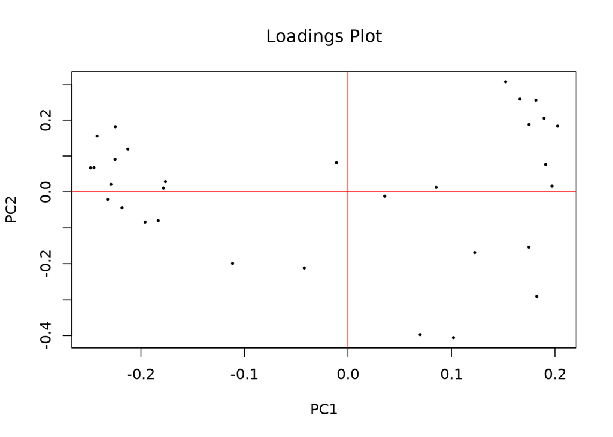

```
## [1] "sdev"       "rotation"   "center"     "scale"      "x"
## [6] "importance"
```

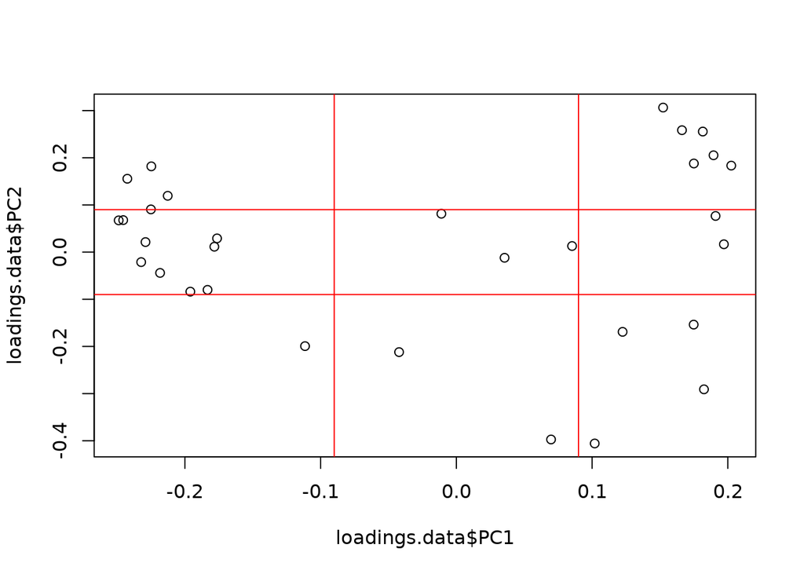

```
##                    PC1        PC2         PC3
## An           0.1662417 0.25844681 -0.11973124
## Et           0.1523376 0.30637266 -0.08157334
## DHEA         0.2025523 0.18333801  0.04907725
## X16a.OH.DHEA 0.1750034 0.18781031 -0.03204235
## A5.3b.17a    0.1909980 0.07661522  0.08864068
## A5.3b.17b    0.1815747 0.25552617  0.07424375
```

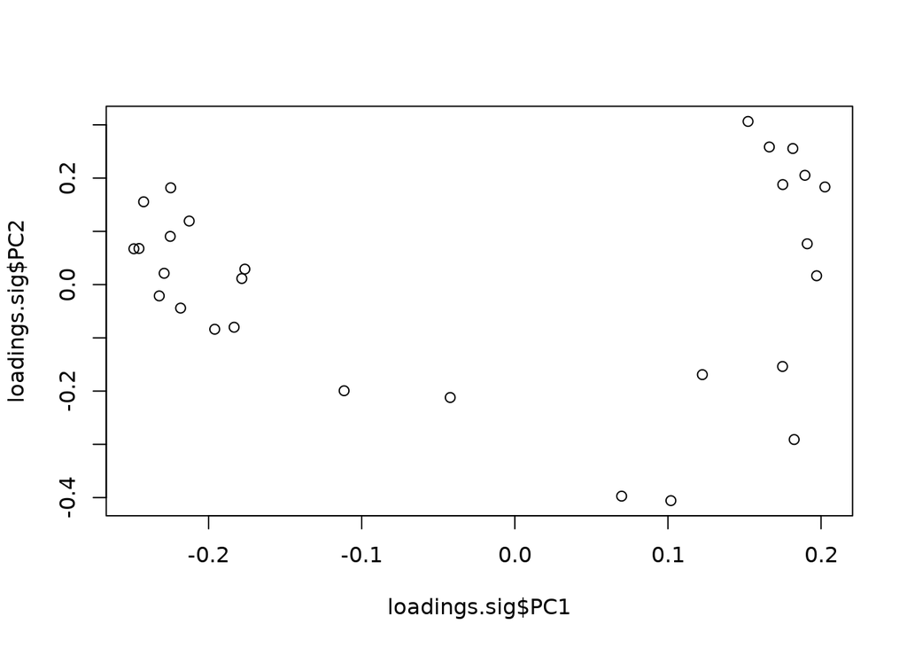

### Heatmap

To display the data in a complete manner, a heatmap is able to show what variance there is in our dataset.

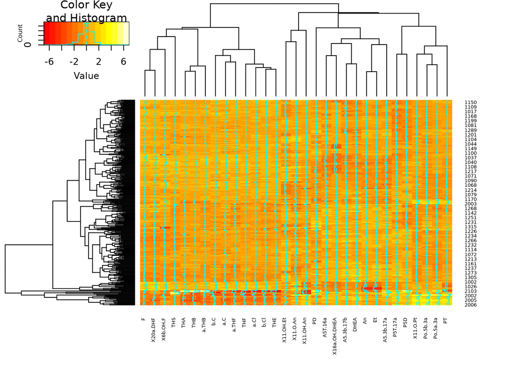

## Clustering

Now that we have analysed our heatmap, we could come to the conclusion, that there are five clusters, there seem to be different bands of variants in there.

If we however calculate the optimal amount of clusters for our dataset with k-means, we will get only two clusters. This is an issue that we were unable to solve.

```r
library(factoextra)
```

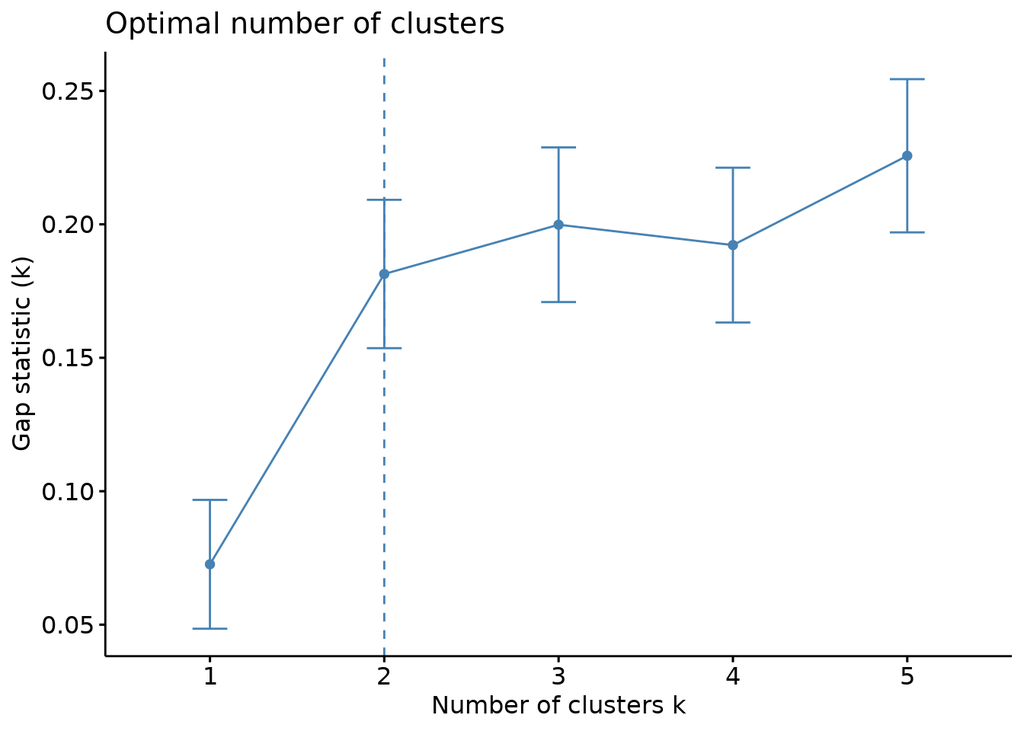

```r
library(cluster)
library(ggplot2)

gap_stat <- clusGap(t(logdata.pareto),
  FUN = kmeans,
  K.max = 5
)

# Plot the optimal cluster count
fviz_gap_stat(gap_stat)
```

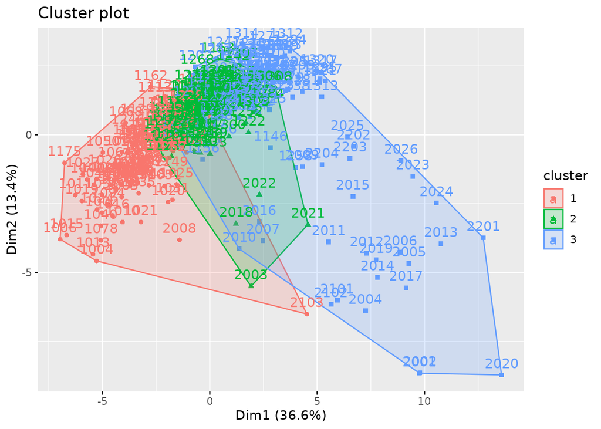

```r
# Cluster the dataset
result <- (clara(logdata.pareto, 3))

# Plot the calculated cluster
fviz_cluster(result, data = logdata.pareto)
```

### Data Conversion

To add a new column to our dataset we use `tibble` and firstly turn our data into a `DataFrame` and further add a new column with `add_column`

```r
library(tibble)
clustered_data <- as.data.frame(logdata.pareto) %>% add_column(cluster = result$clustering)
```

## Add Ratios and Sums

Since metabolite levels are a bit too much to work with in the long run, we used the sums and ratios to remove complexity of our datasets

```r
sums <- function(val) {
  df <- data.frame(matrix(nrow = nrow(val), ncol = 0))

  c19 <- c("An", "Et", "A5.3b.17b", "DHEA", "X16a.OH.DHEA", "A5T.16a")
  c21 <- c("a.THF", "THF", "THE", "a.C", "b.C", "a.Cl", "b.Cl")
  progesterone <- c("PT", "Po.5b.3a", "Po.5a.3a", "P5T.17a")
  cortisole <- c("THE", "THF", "a.THF",
    "a.Cl", "b.Cl", "a.C", "b.C", "X6b.OH.F",
    "X20a.DHF", "X11.OH.An", "X11.OH.Et", "THA", "THB", "a.THB", c19)

  df$c19 <- apply(val[c19], 1, sum)
  df$c21 <- apply(val[c21], 1, sum)
  df$progesterone <- apply(val[progesterone], 1, sum)
  df$cortisole <- apply(val[cortisole], 1, sum)

  return(df)
}
```

```r
ratios <- function(y) {
  df <- data.frame(matrix(nrow = nrow(y), ncol = 0))

  df$relative_overall_androgen_production_1 <- apply(y, 1, \(x)    {
    return(
      (x["An"] + x["Et"]) / (x["a.THF"] + x["THF"] + x["THE"])
    )
  })

  df$relative_overall_androgen_production_2 <- apply(y, 1, \(x) {
    return(
      (x["An"] + x["Et"] + x["A5.3b.17a"] + x["A5.3b.17b"] + x["DHEA"] + x["X16a.OH.DHEA"] + x["A5T.16a"]) / (x["a.THF"] + x["THF"] + x["THE"])
      )
  })



  df$relative_adrenal_androgen_production_1 <- apply(y, 1, \(x) {
    return((x["DHEA"]) / (x["a.THF"] + x["THF"] + x["THE"]))
  })

  df$relative_adrenal_androgen_production_2 <- apply(y, 1, \(x) {
    return((x["DHEA"] + x["X16a.OH.DHEA"] + x["A5T.16a"]) / (x["a.THF"] + x["THF"] + x["THE"]))
  })



  df$relative_overproduction_of_3bHSD_1 <- apply(y, 1, \(x) {
    return(x["DHEA"] / (x["An"] + x["Et"]))
  })

  df$relative_overproduction_of_3bHSD_2 <- apply(y, 1, \(x) {
    return((x["DHEA"] + x["X16a.OH.DHEA"] + x["A5T.16a"]) / (x["An"] + x["Et"]))
  })

  df$relative_overproduction_of_3bHSD_3 <- apply(y, 1, \(x) {
    return((x["DHEA"] + x["X16a.OH.DHEA"] + x["A5T.16a"]) / (x["a.THF"] + x["THE"] + x["THF"]))
  })

  df$relative_overproduction_of_3bHSD_4 <- apply(y, 1, \(x) {
    return(x["P5T.17a"] / (x["a.THF"] + x["THF"] + x["THE"]))
  })

  df$relative_overproduction_of_3bHSD_5 <- apply(y, 1, \(x) {
    return(x["P5T.17a"] / x["PT"])
  })



  df$X21_hydroxylase_activity_1 <- apply(y, 1, \(x) {
    return((x["PT"] + x["Po.5b.3a"] + x["Po.5a.3a"]) / (x["a.THF"] + x["THF"] + x["THE"]))
  })

  df$X21_hydroxylase_activity_2 <- apply(y, 1, \(x) {
    return((x["X11.O.Pt"] + x["PT"] + x["Po.5b.3a"] + x["Po.5a.3a"]) / (x["a.THF"] + x["THF"] + x["THE"]))
  })

  df$X21_hydroxylase_activity_3 <- apply(y, 1, \(x) {
    return((x["X11.O.Pt"]) / (x["a.THF"] + x["THF"] + x["THE"]))
  })

  df$X21_hydroxylase_activity_4 <- apply(y, 1, \(x) {
    return(x["X11.O.Pt"] / x["a.Cl"])
  })



  df$X11b_hydroxylase_activity_1 <- apply(y, 1, \(x) {
    return(x["THS"] / (x["a.THF"] + x["THF"] + x["THE"]))
  })

  df$X11b_hydroxylase_activity_2 <- apply(y, 1, \(x) {
    return((x["An"] + x["Et"]) / (x["X11.OH.An"] + x["X11.OH.Et"]))
  })



  df$X17_hydroxylase_activity_global <- apply(y, 1, \(x) {
    return((x["THA"] + x["THB"] + x["a.THB"]) / (x["An"] + x["Et"]))
  })

  df$X17_hydroxylase_activity_17a_hydroxylase_activity_d5 <- apply(y, 1, \(x) {
    return(x["P5D"] / x["P5T.17a"])
  })

  df$X17_hydroxylase_activity_17a_hydroxylase_activity_d4 <- apply(y, 1, \(x) {
    return(x["PD"] / x["PT"])
  })

  df$X17_hydroxylase_activity_17a_hydroxylase_activity_global <- apply(y, 1, \(x) {
    return((x["a.THF"] + x["THF"] + x["THE"]) / (x["An"] + x["Et"]))
  })

  return(df)
}
```

```r
combined_df <- cbind(clustered_data, ratios(dat2))
combined_df <- cbind(combined_df, sums(dat2))
```

## Cluster based Plotting

### Boxplot per Cluster

Firstly we plot a boxplot for each cluster.

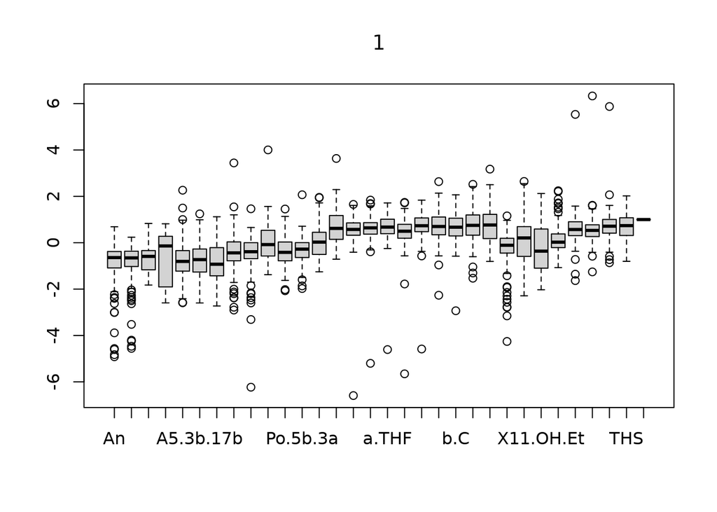

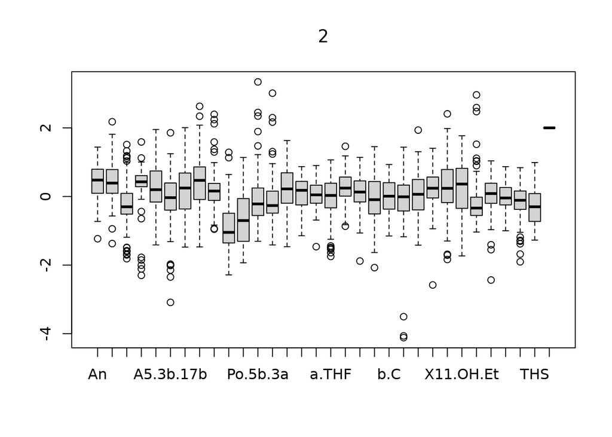

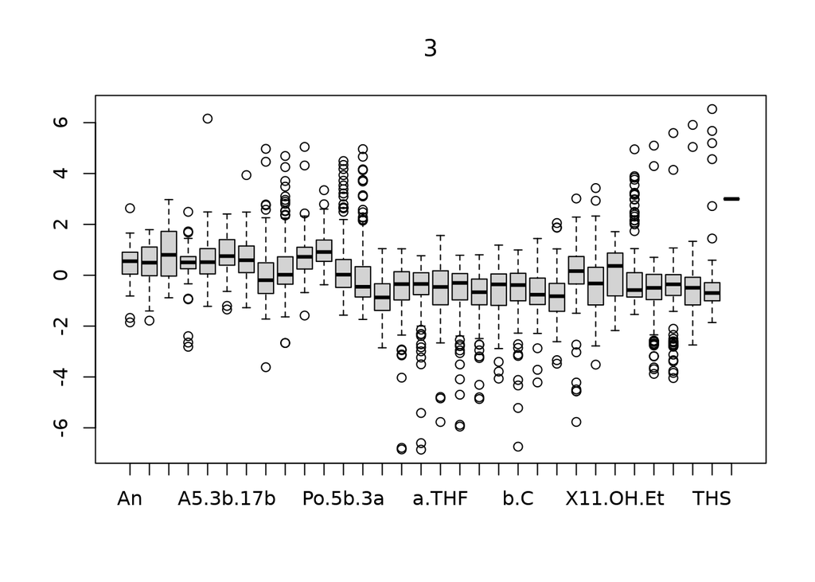

### Line of median metabolite for each cluster

```r
median_cluster <- list()
for (cluster in unique(clustered_data$cluster)) {
  median_cluster[[cluster]] <- apply(clustered_data[clustered_data$cluster == cluster, ], 2, median)
}
```

[figure not shown]

```r
# Little helper function to create multiple colors in a plot, could probably benefit from a few more
line_colors <- c("blue", "red", "green")
new_color <- function(x) {
  return(line_colors[[(x %% length(line_colors)) + 1]])
}
```

### Boxplot for each cluster for the sums

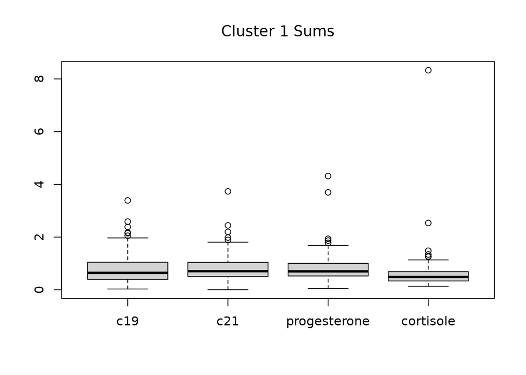

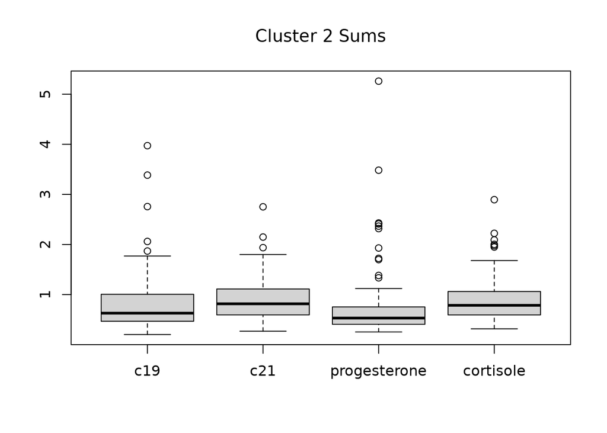

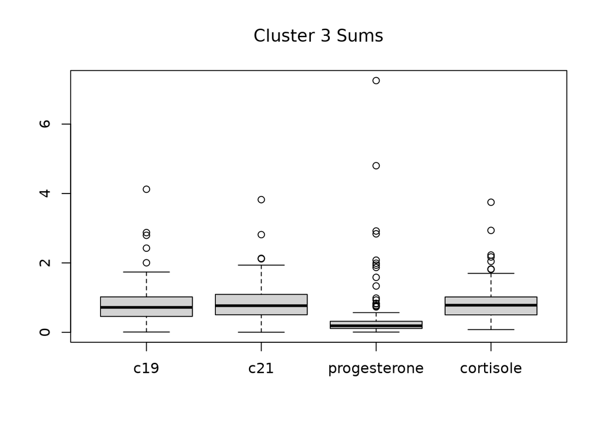

### Heatmap for the Ratios

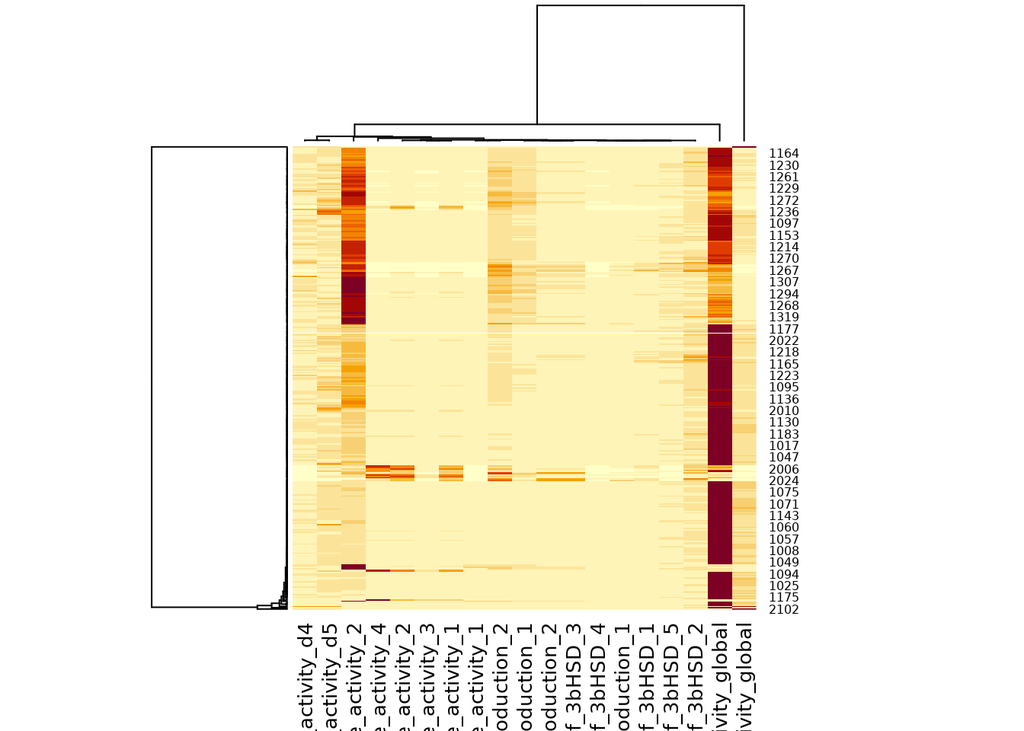

### Metabolite Concentration per Cluster

```r
median_cluster <- list()
for (cluster in unique(combined_df$cluster)) {
  median_cluster[[cluster]] <- apply(combined_df[combined_df$cluster == cluster, ], 2, median)
}
```

[figure not shown]

### Heatmap for each ratio based on the clusters

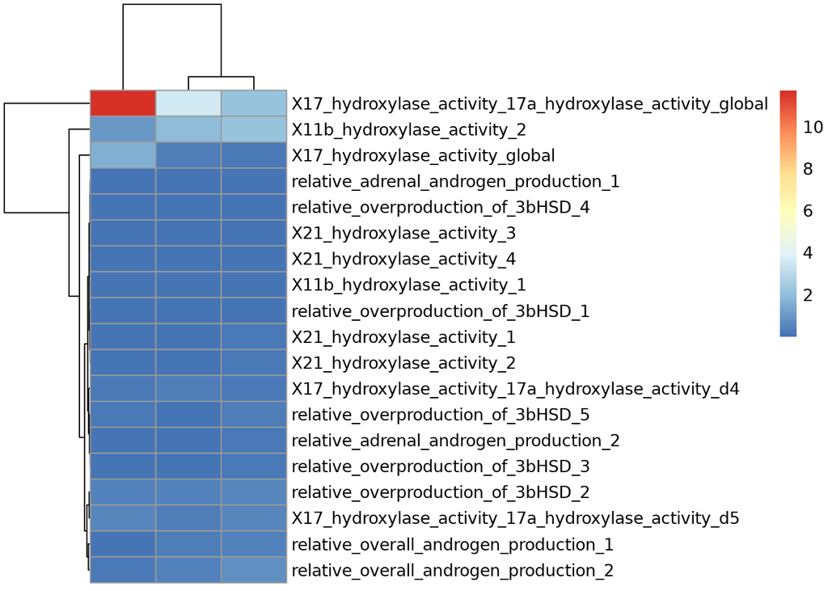

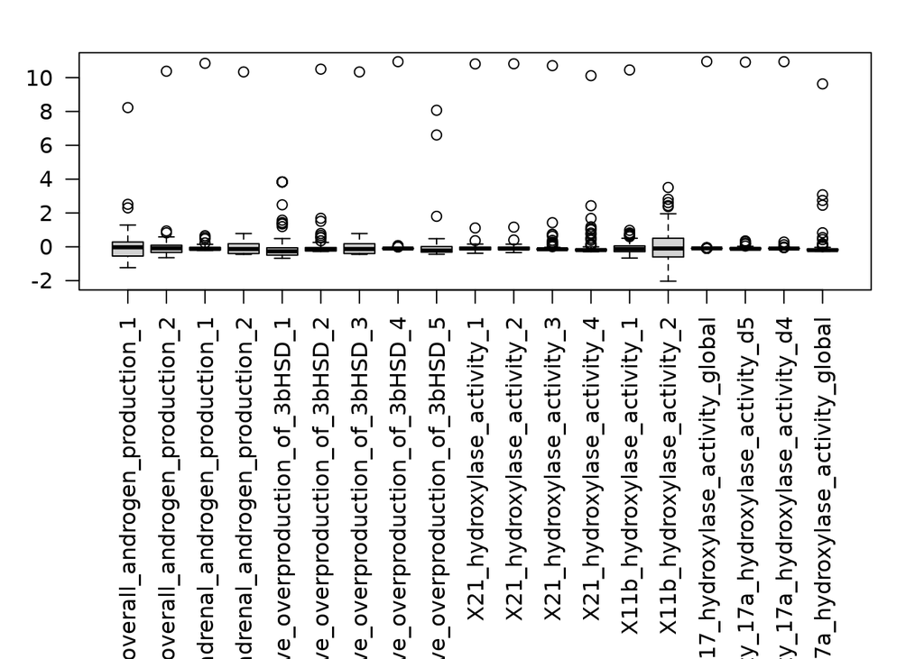

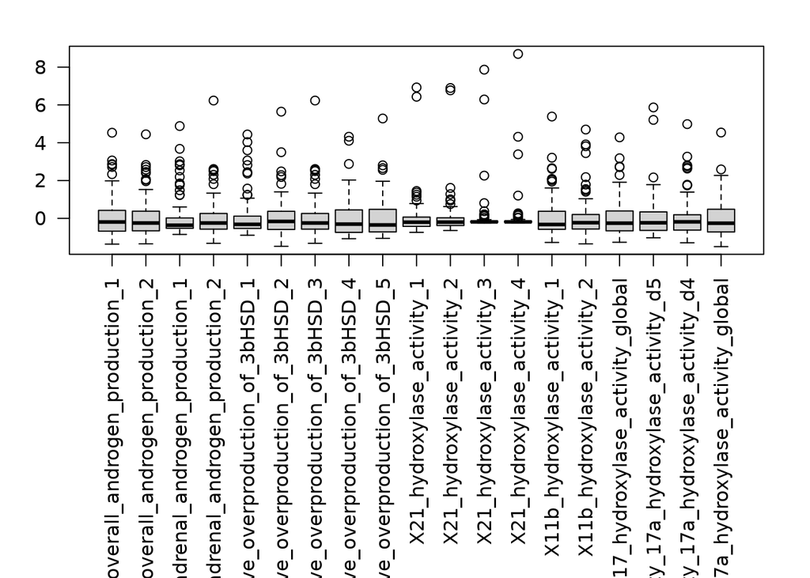

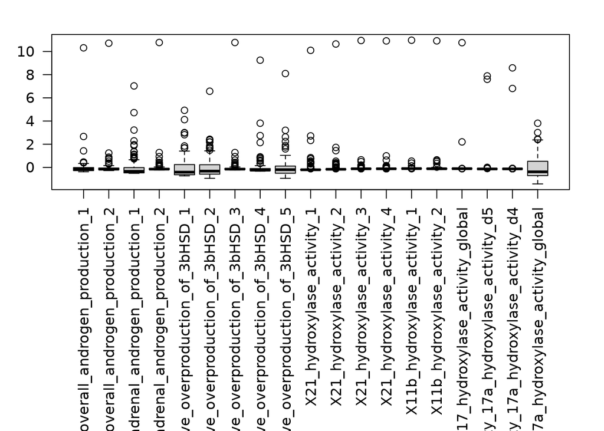